# Question 1:

```python
import pandas as pd


shopify_data = pd.read_excel("C:/Users/Mouna/Desktop/Jobs/Shopify/2019 Winter Data Science Intern Challenge Data Set.xlsx")
shopify_data.head()
```

|  | order_id | shop_id | user_id | order_amount | total_items | payment_method | created_at |
| --- | --- | --- | --- | --- | --- | --- | --- |
| 0 | 1 | 53 | 746 | 224 | 2 | cash | 2017-03-13 12:36:56.190 |
| 1 | 2 | 92 | 925 | 90 | 1 | cash | 2017-03-03 17:38:51.999 |
| 2 | 3 | 44 | 861 | 144 | 1 | cash | 2017-03-14 04:23:55.595 |
| 3 | 4 | 18 | 935 | 156 | 1 | credit_card | 2017-03-26 12:43:36.649 |
| 4 | 5 | 18 | 883 | 156 | 1 | credit_card | 2017-03-01 04:35:10.773 |

```python
shopify_data.describe()
```

|  | order_id | shop_id | user_id | order_amount | total_items |
| --- | --- | --- | --- | --- | --- |
| count | 5000.000000 | 5000.000000 | 5000.000000 | 5000.000000 | 5000.00000 |
| mean | 2500.500000 | 50.078800 | 849.092400 | 3145.128000 | 8.78720 |
| std | 1443.520003 | 29.006118 | 87.798982 | 41282.539349 | 116.32032 |
| min | 1.000000 | 1.000000 | 607.000000 | 90.000000 | 1.00000 |
| 25% | 1250.750000 | 24.000000 | 775.000000 | 163.000000 | 1.00000 |
| 50% | 2500.500000 | 50.000000 | 849.000000 | 284.000000 | 2.00000 |
| 75% | 3750.250000 | 75.000000 | 925.000000 | 390.000000 | 3.00000 |
| max | 5000.000000 | 100.000000 | 999.000000 | 704000.000000 | 2000.00000 |

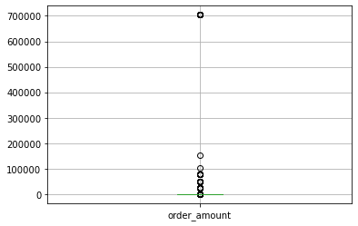

```python
shopify_data.boxplot(column='order_amount')
```

# Analysis of order_amount

Following observations are derived from the data -

1) min and 25% values of total_items is 1, but their corresponding order_amount is different, i.e min order_amount is 90 and 25% order_amount is 163. Since all the shops are selling the same shoe model, this means each shop sells the same shoe for a different price

2) There are observations with total_items as 2000 whose order_amount is 704000. This is seen from the max value above. Due to this outlier, the mean of the order_amount is shifting to a higher value of 3145.128. This gives a wrong notion of the montly average being of this value. The standard deviation 41282.5 signifies the values deviating from the mean by a large amount. In such scenarios with the presence of outliers, we can use median to determine an average value. Another approach can be to discard the values beyond +/-1.5 IQR(Inter quartile range) and then take the mean value.

# a) Think about what could be going wrong with our calculation. Think about a better way to evaluate this data.

```python
shopify_data['order_amount'].mean() #This is the mean of the order_amount from the dataset which is wrong. We need to divide by total no. of items
```

```
3145.128
```

# b) What metric would you report for this dataset?

```python
total_order_amount = shopify_data['order_amount'].sum()
total_number_of_items = shopify_data['total_items'].sum()
print(total_order_amount)
print(total_number_of_items)
```

```
15725640
43936
```

# c) What is its value?

```python
print(total_order_amount/total_number_of_items)
```

```
357.92152221412965
```

# Question 2:

# a) How many orders were shipped by Speedy Express in total?

```python
SELECT COUNT(*)
FROM Orders JOIN Shippers ON Orders.ShipperID = Shippers.ShipperID
WHERE Shippers.ShipperName='Speedy Express';
```

```python
Answer -
54
```

# b) What is the last name of the employee with the most orders?

```python
SELECT Employees.LastName
FROM Orders JOIN Employees ON Orders.EmployeeID = Employees.EmployeeID
GROUP BY LastName
ORDER BY COUNT(*) DESC
LIMIT 1;
```

```python
Answer -
Peacock
```

# c) What product was ordered the most by customers in Germany?

```python
CREATE VIEW GermanyCustomerOrders AS
SELECT Orders.OrderID, Customers.Country, OrderDetails.Quantity, Products.ProductName
FROM Orders, OrderDetails
JOIN Customers ON Orders.CustomerID=Customers.CustomerID
JOIN Products ON OrderDetails.ProductID=Products.ProductID
WHERE Country='Germany';

CREATE VIEW ProductOrders AS
SELECT ProductName, Quantity, COUNT(*) as 'Orders'
FROM GermanyCustomerOrders
GROUP BY ProductName;


SELECT ProductName
FROM ProductOrders
ORDER BY (Quantity * Orders) desc
LIMIT 1;
```

```python
Answer -
Camembert Pierrot
```